# Loan Interest Rate Prediction Data Visualization

## Aim: To analyze the customer data provided after EDA.

## Problem Statement :

### To predict Interest Rate based on given customer data.

- ID -- Unique Loan ID
- Amount.Requested -- Amount of money requested by the borrower
- Interest. Rate -- Interest Rate on the loan [<- Dependent variable]
- Loan. Length -- Number of payments (36 or 60)
- Loan. Purpose -- Reason for loan provided by borrower
- Debt.To.Income.Ratio -- All your monthly debt payments divided by your gross monthly income
- Home. Ownership -- Home ownership status: (RENT, OWN, MORTGAGE, OTHERS)
- Monthly. Income -- Monthly income of borrower
- Open. CREDIT. Lines -- The number of open credit lines
- Revolving.CREDIT. Balance -- Type of credit Balance that can be used repeatedly up to a certain limit as long as the account is open, and payments are made on time. With revolving credit, the amount of available credit
- Inquiries.in.the.Last.6.Months -- A credit inquiry is a request by an institution for credit report information from a credit reporting agency
- Employment.Length – Employment period
- FICO -- FICO credit score of the borrower (https://www.investopedia.com/terms/f/ficoscore.asp)

### IMPORTING LIBRARIES &

```python
import re
import numpy as np
import pandas as pd
import matplotlib.pyplot as plt
import seaborn as sns
from scipy import stats
from scipy.stats.mstats import winsorize
from sklearn.preprocessing import OrdinalEncoder
import math
import statsmodels.api as sm
%matplotlib inline
```

```python
loan_intrt_data = pd.read_csv(r'C:\Users\RONALD\Desktop\IMS-Classroom\Python Code\Resume Project - ML Algo\Loan Interest Rate prediction\loans data_new.csv')
loan_intrt_data.head(10)
```

|  | ID | Amount.Requested | Amount.Funded.By.Investors | Interest.Rate | Loan.Length | Loan.Purpose | Debt.To.Income.Ratio | Home.Ownership | Monthly.Income | Open.CREDIT.Lines | Revolving.CREDIT.Balance | Inquiries.in.the.Last.6.Months | Employment.Length | fico |
| --- | --- | --- | --- | --- | --- | --- | --- | --- | --- | --- | --- | --- | --- | --- |
| 0 | 81174.0 | 20000 | 20000.0 | 0.09 | 36 months | debt_consolidation | 0.15 | MORTGAGE | 6541.67 | 14 | 14272 | 2 | 1 year | 735-739 |
| 1 | 99592.0 | 19200 | 19200.0 | 0.12 | 36 months | debt_consolidation | 0.28 | MORTGAGE | 4583.33 | 12 | 11140 | 1 | 2 years | 715-719 |
| 2 | 80059.0 | 35000 | 35000.0 | 0.22 | 60 months | debt_consolidation | 0.24 | MORTGAGE | 11500.00 | 14 | 21977 | 1 | 2 years | 690-694 |
| 3 | 15825.0 | 10000 | 9975.0 | 0.10 | 36 months | debt_consolidation | 0.14 | MORTGAGE | 3833.33 | 10 | 9346 | 0 | 5 years | 695-699 |
| 4 | 33182.0 | 12000 | 12000.0 | 0.12 | 36 months | credit_card | 0.19 | RENT | 3195.00 | 11 | 14469 | 0 | 9 years | 695-699 |
| 5 | 62403.0 | 6000 | 6000.0 | 0.15 | 36 months | other | 0.20 | OWN | 4891.67 | 17 | 10391 | 2 | 3 years | 670-674 |
| 6 | 48808.0 | 10000 | 10000.0 | 0.08 | 36 months | debt_consolidation | 0.26 | RENT | 2916.67 | 10 | 15957 | 0 | 10+ years | 720-724 |
| 7 | 22090.0 | 33500 | 33450.0 | 0.17 | 60 months | credit_card | 0.15 | MORTGAGE | 13863.42 | 12 | 27874 | 0 | 10+ years | 705-709 |
| 8 | 76404.0 | 14675 | 14675.0 | 0.14 | 36 months | credit_card | 0.27 | RENT | 3150.00 | 9 | 7246 | 1 | 8 years | 685-689 |
| 9 | 15867.0 | 1000 | 7000.0 | 0.07 | 36 months | credit_card | 0.07 | RENT | 5000.00 | 8 | 7612 | 0 | 3 years | 715-719 |

### EXPLORE THE DATA

```python
loan_intrt_data.info()
```

```
<class 'pandas.core.frame.DataFrame'>
RangeIndex: 2500 entries, 0 to 2499
Data columns (total 14 columns):
 #   Column                          Non-Null Count  Dtype
---  ------                          --------------  -----
 0   ID                              2499 non-null   float64
 1   Amount.Requested                2500 non-null   int64
 2   Amount.Funded.By.Investors      2500 non-null   float64
 3   Interest.Rate                   2500 non-null   float64
 4   Loan.Length                     2499 non-null   object
 5   Loan.Purpose                    2499 non-null   object
 6   Debt.To.Income.Ratio            2500 non-null   float64
 7   Home.Ownership                  2499 non-null   object
 8   Monthly.Income                  2500 non-null   float64
 9   Open.CREDIT.Lines               2500 non-null   int64
 10  Revolving.CREDIT.Balance        2500 non-null   int64
 11  Inquiries.in.the.Last.6.Months  2500 non-null   int64
 12  Employment.Length               2422 non-null   object
 13  fico                            2500 non-null   object
dtypes: float64(5), int64(4), object(5)
memory usage: 273.6+ KB
```

```python
loan_intrt_data.describe()
```

|  | ID | Amount.Requested | Amount.Funded.By.Investors | Interest.Rate | Debt.To.Income.Ratio | Monthly.Income | Open.CREDIT.Lines | Revolving.CREDIT.Balance | Inquiries.in.the.Last.6.Months |
| --- | --- | --- | --- | --- | --- | --- | --- | --- | --- |
| count | 2499.000000 | 2500.000000 | 2500.000000 | 2500.000000 | 2500.000000 | 2500.000000 | 2500.000000 | 2500.000000 | 2500.000000 |
| mean | 51643.325330 | 12389.590000 | 11984.346044 | 0.130396 | 0.153752 | 5685.153348 | 10.060800 | 15225.668800 | 0.910400 |
| std | 30053.637661 | 7814.420929 | 7743.480223 | 0.041301 | 0.075164 | 3963.376189 | 4.516687 | 18308.723678 | 1.235064 |
| min | 10.000000 | 1000.000000 | 200.000000 | 0.050000 | 0.000000 | 588.500000 | 2.000000 | 0.000000 | 0.000000 |
| 25% | 26570.500000 | 6000.000000 | 6000.000000 | 0.100000 | 0.100000 | 3474.267500 | 7.000000 | 5545.250000 | 0.000000 |
| 50% | 50673.000000 | 10000.000000 | 10000.000000 | 0.130000 | 0.150000 | 5000.000000 | 9.000000 | 10938.000000 | 1.000000 |
| 75% | 77583.000000 | 17000.000000 | 16000.000000 | 0.160000 | 0.210000 | 6800.000000 | 13.000000 | 18870.250000 | 1.000000 |
| max | 104202.000000 | 35000.000000 | 35000.000000 | 0.250000 | 0.350000 | 102750.000000 | 38.000000 | 270800.000000 | 9.000000 |

```python
loan_intrt_data.describe(include='object')
```

|  | Loan.Length | Loan.Purpose | Home.Ownership | Employment.Length | fico |
| --- | --- | --- | --- | --- | --- |
| count | 2499 | 2499 | 2499 | 2422 | 2500 |
| unique | 3 | 14 | 5 | 10 | 38 |
| top | 36 months | debt_consolidation | MORTGAGE | 10+ years | 670-674 |
| freq | 1950 | 1307 | 1147 | 653 | 171 |

### UNIVARIATE ANALYSIS

#### A. Rename columns

```python
#rename columns
loan_intrt_data.columns = ['ID','Amount_Requested','Amount_Funded_By_Investors','Interest_Rate','Loan_Length','Loan_Purpose',
                          'Debt_To_Income_Ratio','Home_Ownership','Monthly_Income','Open_Credit_Lines','Revolving_Credit_Balance',
                          'Inquiries_in_the_last_6months','Employment_Length','FICO_Score']

loan_intrt_data.columns
```

```
Index(['ID', 'Amount_Requested', 'Amount_Funded_By_Investors', 'Interest_Rate',
       'Loan_Length', 'Loan_Purpose', 'Debt_To_Income_Ratio', 'Home_Ownership',
       'Monthly_Income', 'Open_Credit_Lines', 'Revolving_Credit_Balance',
       'Inquiries_in_the_last_6months', 'Employment_Length', 'FICO_Score'],
      dtype='object')
```

##### Unique Values for each feature

```python
for i in range(loan_intrt_data.shape[1]):
    col_name = loan_intrt_data.columns[i]
    print('Column Name: ', col_name)
    print(loan_intrt_data[col_name].value_counts())
    print('--------- ')
```

```
Column Name:  ID
29981.0     1
7606.0      1
51795.0     1
79308.0     1
95827.0     1
           ..
101715.0    1
58739.0     1
35834.0     1
46337.0     1
9664.0      1
Name: ID, Length: 2499, dtype: int64
---------
Column Name:  Amount_Requested
10000    205
12000    150
5000     110
20000    107
6000     103
        ...
9700       1
7625       1
15300      1
1450       1
16350      1
Name: Amount_Requested, Length: 380, dtype: int64
---------
Column Name:  Amount_Funded_By_Investors
10000.00    164
12000.00    108
5000.00      87
6000.00      84
8000.00      69
           ...
4525.00       1
2450.00       1
3100.00       1
5795.24       1
6350.01       1
```

[output cut: 208 more lines]

```
785-789     19
770-774     17
795-799     13
800-804     13
805-809     11
810-814      8
815-819      6
640-644      5
655-659      4
645-649      3
650-654      1
820-824      1
830-834      1
Name: FICO_Score, dtype: int64
---------
```

```python
loan_intrt_data.head(10)
```

|  | ID | Amount_Requested | Amount_Funded_By_Investors | Interest_Rate | Loan_Length | Loan_Purpose | Debt_To_Income_Ratio | Home_Ownership | Monthly_Income | Open_Credit_Lines | Revolving_Credit_Balance | Inquiries_in_the_last_6months | Employment_Length | FICO_Score |
| --- | --- | --- | --- | --- | --- | --- | --- | --- | --- | --- | --- | --- | --- | --- |
| 0 | 81174.0 | 20000 | 20000.0 | 0.09 | 36 months | debt_consolidation | 0.15 | MORTGAGE | 6541.67 | 14 | 14272 | 2 | 1 year | 735-739 |
| 1 | 99592.0 | 19200 | 19200.0 | 0.12 | 36 months | debt_consolidation | 0.28 | MORTGAGE | 4583.33 | 12 | 11140 | 1 | 2 years | 715-719 |
| 2 | 80059.0 | 35000 | 35000.0 | 0.22 | 60 months | debt_consolidation | 0.24 | MORTGAGE | 11500.00 | 14 | 21977 | 1 | 2 years | 690-694 |
| 3 | 15825.0 | 10000 | 9975.0 | 0.10 | 36 months | debt_consolidation | 0.14 | MORTGAGE | 3833.33 | 10 | 9346 | 0 | 5 years | 695-699 |
| 4 | 33182.0 | 12000 | 12000.0 | 0.12 | 36 months | credit_card | 0.19 | RENT | 3195.00 | 11 | 14469 | 0 | 9 years | 695-699 |
| 5 | 62403.0 | 6000 | 6000.0 | 0.15 | 36 months | other | 0.20 | OWN | 4891.67 | 17 | 10391 | 2 | 3 years | 670-674 |
| 6 | 48808.0 | 10000 | 10000.0 | 0.08 | 36 months | debt_consolidation | 0.26 | RENT | 2916.67 | 10 | 15957 | 0 | 10+ years | 720-724 |
| 7 | 22090.0 | 33500 | 33450.0 | 0.17 | 60 months | credit_card | 0.15 | MORTGAGE | 13863.42 | 12 | 27874 | 0 | 10+ years | 705-709 |
| 8 | 76404.0 | 14675 | 14675.0 | 0.14 | 36 months | credit_card | 0.27 | RENT | 3150.00 | 9 | 7246 | 1 | 8 years | 685-689 |
| 9 | 15867.0 | 1000 | 7000.0 | 0.07 | 36 months | credit_card | 0.07 | RENT | 5000.00 | 8 | 7612 | 0 | 3 years | 715-719 |

### Correlation Matrix

|  | ID | Amount_Requested | Amount_Funded_By_Investors | Interest_Rate | Debt_To_Income_Ratio | Monthly_Income | Open_Credit_Lines | Revolving_Credit_Balance | Inquiries_in_the_last_6months |
| --- | --- | --- | --- | --- | --- | --- | --- | --- | --- |
| ID | 1.000000 | 0.129807 | 0.172535 | 0.240340 | 0.240415 | 0.004573 | 0.176874 | 0.076966 | 0.141670 |
| Amount_Requested | 0.129807 | 1.000000 | 0.964836 | 0.334903 | 0.082178 | 0.390384 | 0.197074 | 0.294000 | -0.030577 |
| Amount_Funded_By_Investors | 0.172535 | 0.964836 | 1.000000 | 0.339982 | 0.098727 | 0.372001 | 0.190009 | 0.264346 | -0.068574 |
| Interest_Rate | 0.240340 | 0.334903 | 0.339982 | 1.000000 | 0.168604 | 0.016809 | 0.090567 | 0.061837 | 0.161515 |
| Debt_To_Income_Ratio | 0.240415 | 0.082178 | 0.098727 | 0.168604 | 1.000000 | -0.163904 | 0.368262 | 0.187780 | 0.006425 |
| Monthly_Income | 0.004573 | 0.390384 | 0.372001 | 0.016809 | -0.163904 | 1.000000 | 0.169300 | 0.357377 | 0.035650 |
| Open_Credit_Lines | 0.176874 | 0.197074 | 0.190009 | 0.090567 | 0.368262 | 0.169300 | 1.000000 | 0.291094 | 0.107789 |
| Revolving_Credit_Balance | 0.076966 | 0.294000 | 0.264346 | 0.061837 | 0.187780 | 0.357377 | 0.291094 | 1.000000 | 0.009803 |
| Inquiries_in_the_last_6months | 0.141670 | -0.030577 | -0.068574 | 0.161515 | 0.006425 | 0.035650 | 0.107789 | 0.009803 | 1.000000 |

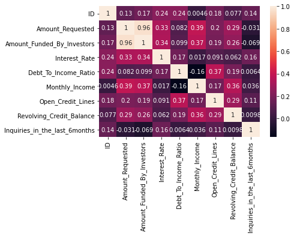

```python
corr = loan_intrt_data.corr()
display(corr)
sns.heatmap(corr, annot=True)
```

```
### Amount_Requested and Amoumt_Requested_By_Investors are correlated
```

### Data Cleaning & Formatting

#### B. Missing Values Identification & Treatment

```python
### Missing Values
loan_intrt_data.isnull().sum(axis=0)
```

```
ID                                1
Amount_Requested                  0
Amount_Funded_By_Investors        0
Interest_Rate                     0
Loan_Length                       1
Loan_Purpose                      1
Debt_To_Income_Ratio              0
Home_Ownership                    1
Monthly_Income                    0
Open_Credit_Lines                 0
Revolving_Credit_Balance          0
Inquiries_in_the_last_6months     0
Employment_Length                78
FICO_Score                        0
dtype: int64
```

```python
loan_data = loan_intrt_data.copy()     #------ copy dataset
loan_data.shape
```

```
(2500, 14)
```

```python
loan_data_ID = loan_data[['ID']] #--- drop ID
loan_data_ID
```

|  | ID |
| --- | --- |
| 0 | 81174.0 |
| 1 | 99592.0 |
| 2 | 80059.0 |
| 3 | 15825.0 |
| 4 | 33182.0 |
| ... | ... |
| 2495 | 23735.0 |
| 2496 | 65882.0 |
| 2497 | 55610.0 |
| 2498 | 38576.0 |
| 2499 | 3116.0 |

2500 rows × 1 columns

```python
#Splitting Numerical & Categorical columns

#loan_data_num_cols = final dataset with Numerical columns
#loan_data_cat_cols = final dataset with Categorical columns
with_num_cols_data = loan_data[loan_data.select_dtypes(include=[np.number]).columns.tolist()]
with_cat_cols_data = loan_data[loan_data.select_dtypes(exclude=[np.number]).columns.tolist()]
```

```python
with_num_cols_data.head()
```

|  | ID | Amount_Requested | Amount_Funded_By_Investors | Interest_Rate | Debt_To_Income_Ratio | Monthly_Income | Open_Credit_Lines | Revolving_Credit_Balance | Inquiries_in_the_last_6months |
| --- | --- | --- | --- | --- | --- | --- | --- | --- | --- |
| 0 | 81174.0 | 20000 | 20000.0 | 0.09 | 0.15 | 6541.67 | 14 | 14272 | 2 |
| 1 | 99592.0 | 19200 | 19200.0 | 0.12 | 0.28 | 4583.33 | 12 | 11140 | 1 |
| 2 | 80059.0 | 35000 | 35000.0 | 0.22 | 0.24 | 11500.00 | 14 | 21977 | 1 |
| 3 | 15825.0 | 10000 | 9975.0 | 0.10 | 0.14 | 3833.33 | 10 | 9346 | 0 |
| 4 | 33182.0 | 12000 | 12000.0 | 0.12 | 0.19 | 3195.00 | 11 | 14469 | 0 |

```python
with_num_cols_data.columns  #numerical columns
```

```
Index(['ID', 'Amount_Requested', 'Amount_Funded_By_Investors', 'Interest_Rate',
       'Debt_To_Income_Ratio', 'Monthly_Income', 'Open_Credit_Lines',
       'Revolving_Credit_Balance', 'Inquiries_in_the_last_6months'],
      dtype='object')
```

```python
with_cat_cols_data.columns   #categorical columns
```

```
Index(['Loan_Length', 'Loan_Purpose', 'Home_Ownership', 'Employment_Length',
       'FICO_Score'],
      dtype='object')
```

### Checking for missing value in Numerical features and treating them

```python
def treat_num_columns(col_list):

    for i in col_list:
        col_name = i
        print('Independent Variable: ',col_name)
        print('Check if there are any missing value in variable',col_name,': ')
        if (loan_data[col_name].isnull().any().any() == True):
            print('No. of Observations with missing value: ', loan_data[col_name].isnull().sum(axis=0))
            # Replacing missing values with Median
            loan_data[col_name].fillna(loan_data[col_name].median(), inplace=True)
            print('After treating the missing values')
            print(loan_data[col_name].isnull().sum(axis=0))
            print('')
        else:
            print('No missing values found in ',col_name)
            print('')
```

```python
treat_num_columns(with_num_cols_data.columns)
```

```
Independent Variable:  ID
Check if there are any missing value in variable ID :
No. of Observations with missing value:  1
After treating the missing values
0

Independent Variable:  Amount_Requested
Check if there are any missing value in variable Amount_Requested :
No missing values found in  Amount_Requested

Independent Variable:  Amount_Funded_By_Investors
Check if there are any missing value in variable Amount_Funded_By_Investors :
No missing values found in  Amount_Funded_By_Investors

Independent Variable:  Interest_Rate
Check if there are any missing value in variable Interest_Rate :
No missing values found in  Interest_Rate

Independent Variable:  Debt_To_Income_Ratio
Check if there are any missing value in variable Debt_To_Income_Ratio :
No missing values found in  Debt_To_Income_Ratio

Independent Variable:  Monthly_Income
Check if there are any missing value in variable Monthly_Income :
No missing values found in  Monthly_Income

Independent Variable:  Open_Credit_Lines
Check if there are any missing value in variable Open_Credit_Lines :
No missing values found in  Open_Credit_Lines

Independent Variable:  Revolving_Credit_Balance
Check if there are any missing value in variable Revolving_Credit_Balance :
No missing values found in  Revolving_Credit_Balance

Independent Variable:  Inquiries_in_the_last_6months
Check if there are any missing value in variable Inquiries_in_the_last_6months :
No missing values found in  Inquiries_in_the_last_6months
```

### Checking for missing value in Categorical features and treating them

```python
def treat_cat_columns(cat_col_list):

    for i in cat_col_list:
        col_name = i
        print('Independent Variable: ',col_name)
        print('Check if there are any missing value in variable',col_name,': ')
        if (loan_data[col_name].isnull().any().any() == True):
            print('No. of Observations with missing value: ', loan_data[col_name].isnull().sum(axis=0))
            # Replacing missing values with Mode
            loan_data[col_name].fillna(loan_data[col_name].mode()[0], inplace=True)
            print('After treating the missing values')
            print('No. of Observations with missing value: ', loan_data[col_name].isnull().sum(axis=0))
            print('')
        else:
            print('No missing values found in ',col_name)
            print('')
```

```python
treat_cat_columns(with_cat_cols_data.columns)
```

```
Independent Variable:  Loan_Length
Check if there are any missing value in variable Loan_Length :
No. of Observations with missing value:  1
After treating the missing values
No. of Observations with missing value:  0

Independent Variable:  Loan_Purpose
Check if there are any missing value in variable Loan_Purpose :
No. of Observations with missing value:  1
After treating the missing values
No. of Observations with missing value:  0

Independent Variable:  Home_Ownership
Check if there are any missing value in variable Home_Ownership :
No. of Observations with missing value:  1
After treating the missing values
No. of Observations with missing value:  0

Independent Variable:  Employment_Length
Check if there are any missing value in variable Employment_Length :
No. of Observations with missing value:  78
After treating the missing values
No. of Observations with missing value:  0

Independent Variable:  FICO_Score
Check if there are any missing value in variable FICO_Score :
No missing values found in  FICO_Score
```

```python
loan_data.isnull().sum(axis=0)
```

```
ID                               0
Amount_Requested                 0
Amount_Funded_By_Investors       0
Interest_Rate                    0
Loan_Length                      0
Loan_Purpose                     0
Debt_To_Income_Ratio             0
Home_Ownership                   0
Monthly_Income                   0
Open_Credit_Lines                0
Revolving_Credit_Balance         0
Inquiries_in_the_last_6months    0
Employment_Length                0
FICO_Score                       0
dtype: int64
```

```python
loan_data.groupby("Loan_Length")['ID'].nunique()
```

```
Loan_Length
.               1
36 months    1951
60 months     548
Name: ID, dtype: int64
```

```python
loan_data['Loan_Length'].replace(['.'],['36 months'],inplace=True)
```

```python
loan_data.groupby('Loan_Length')['ID'].nunique()
```

```
Loan_Length
36 months    1952
60 months     548
Name: ID, dtype: int64
```

```python
loan_data['Home_Ownership'].replace(['NONE'],['OTHER'],inplace=True)
```

```
Inference:
The dataset has no missing values in any of the variable.
```

### C. Outlier Identification & Treatment

#### Outlier Identification

```python
def plot_scatter():
    for i in range(with_num_cols_data.shape[1]):
        col = with_num_cols_data.columns[i]

        plt.scatter(with_num_cols_data[col], with_num_cols_data['Interest_Rate'])
        plt.xlabel(col)
        plt.ylabel('Interest_Rate')
        plt.show()
```

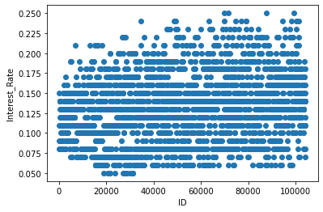

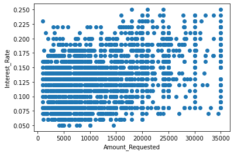

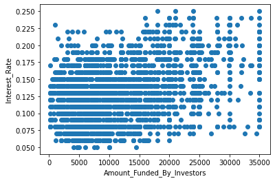

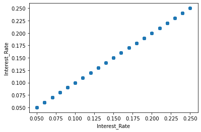

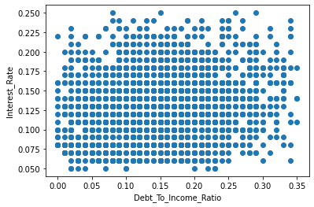

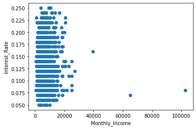

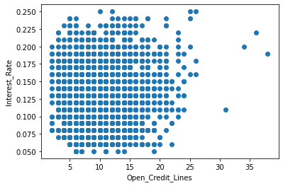

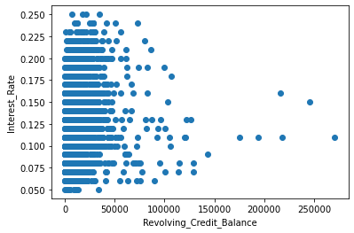

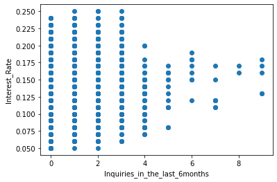

```python
plot_scatter()
```

#### FICO Score

```python
mapping = {'670-674':'Good', '675-679':'Good', '680-684':'Good',
           '695-699' : 'Good', '665-669' : 'Fair', '690-694' : 'Good',
           '685-689' : 'Good', '705-709' : 'Good', '700-704' : 'Good',
           '660-664' : 'Fair', '720-724' : 'Good', '710-714' : 'Good',
           '725-729' : 'Good', '730-734' : 'Good', '715-719' : 'Good',
           '735-739' : 'Good', '750-754' : 'Very Good', '745-749' : 'Very Good',
           '740-744' : 'Very Good', '755-759' : 'Very Good', '760-764' : 'Very Good',
           '765-769' : 'Very Good', '780-784' : 'Very Good', '775-779' : 'Very Good',
           '790-794' : 'Very Good', '785-789' : 'Very Good', '770-774' : 'Very Good',
           '795-799' : 'Very Good', '800-804' : 'Exceptional', '805-809' : 'Exceptional',
           '810-814' : 'Exceptional', '815-819' : 'Exceptional', '640-644' : 'Fair',
           '655-659' : 'Fair', '645-649' : 'Fair', '830-834' : 'Exceptional',
           '820-824' : 'Exceptional', '650-654' : 'Fair'

}
```

```python
with_cat_cols_data['FICO_Score_mapped'] = with_cat_cols_data['FICO_Score'].map(mapping)
```

```python
with_cat_cols_data.head()
```

|  | Loan_Length | Loan_Purpose | Home_Ownership | Employment_Length | FICO_Score | FICO_Score_mapped |
| --- | --- | --- | --- | --- | --- | --- |
| 0 | 36 months | debt_consolidation | MORTGAGE | 1 year | 735-739 | Good |
| 1 | 36 months | debt_consolidation | MORTGAGE | 2 years | 715-719 | Good |
| 2 | 60 months | debt_consolidation | MORTGAGE | 2 years | 690-694 | Good |
| 3 | 36 months | debt_consolidation | MORTGAGE | 5 years | 695-699 | Good |
| 4 | 36 months | credit_card | RENT | 9 years | 695-699 | Good |

```python
with_num_cols_data.columns
```

```
Index(['ID', 'Amount_Requested', 'Amount_Funded_By_Investors', 'Interest_Rate',
       'Debt_To_Income_Ratio', 'Monthly_Income', 'Open_Credit_Lines',
       'Revolving_Credit_Balance', 'Inquiries_in_the_last_6months'],
      dtype='object')
```

```python
with_num_cols_data.isnull().sum(axis=0)
```

```
ID                               1
Amount_Requested                 0
Amount_Funded_By_Investors       0
Interest_Rate                    0
Debt_To_Income_Ratio             0
Monthly_Income                   0
Open_Credit_Lines                0
Revolving_Credit_Balance         0
Inquiries_in_the_last_6months    0
dtype: int64
```

```python
with_cat_cols_data.columns
```

```
Index(['Loan_Length', 'Loan_Purpose', 'Home_Ownership', 'Employment_Length',
       'FICO_Score', 'FICO_Score_mapped'],
      dtype='object')
```

```python
loan_data.head()
```

|  | ID | Amount_Requested | Amount_Funded_By_Investors | Interest_Rate | Loan_Length | Loan_Purpose | Debt_To_Income_Ratio | Home_Ownership | Monthly_Income | Open_Credit_Lines | Revolving_Credit_Balance | Inquiries_in_the_last_6months | Employment_Length | FICO_Score |
| --- | --- | --- | --- | --- | --- | --- | --- | --- | --- | --- | --- | --- | --- | --- |
| 0 | 81174.0 | 20000 | 20000.0 | 0.09 | 36 months | debt_consolidation | 0.15 | MORTGAGE | 6541.67 | 14 | 14272 | 2 | 1 year | 735-739 |
| 1 | 99592.0 | 19200 | 19200.0 | 0.12 | 36 months | debt_consolidation | 0.28 | MORTGAGE | 4583.33 | 12 | 11140 | 1 | 2 years | 715-719 |
| 2 | 80059.0 | 35000 | 35000.0 | 0.22 | 60 months | debt_consolidation | 0.24 | MORTGAGE | 11500.00 | 14 | 21977 | 1 | 2 years | 690-694 |
| 3 | 15825.0 | 10000 | 9975.0 | 0.10 | 36 months | debt_consolidation | 0.14 | MORTGAGE | 3833.33 | 10 | 9346 | 0 | 5 years | 695-699 |
| 4 | 33182.0 | 12000 | 12000.0 | 0.12 | 36 months | credit_card | 0.19 | RENT | 3195.00 | 11 | 14469 | 0 | 9 years | 695-699 |

```python
loan_data['FICO_Score_mapped'] = with_cat_cols_data['FICO_Score_mapped']
loan_data.head()
```

|  | ID | Amount_Requested | Amount_Funded_By_Investors | Interest_Rate | Loan_Length | Loan_Purpose | Debt_To_Income_Ratio | Home_Ownership | Monthly_Income | Open_Credit_Lines | Revolving_Credit_Balance | Inquiries_in_the_last_6months | Employment_Length | FICO_Score | FICO_Score_mapped |
| --- | --- | --- | --- | --- | --- | --- | --- | --- | --- | --- | --- | --- | --- | --- | --- |
| 0 | 81174.0 | 20000 | 20000.0 | 0.09 | 36 months | debt_consolidation | 0.15 | MORTGAGE | 6541.67 | 14 | 14272 | 2 | 1 year | 735-739 | Good |
| 1 | 99592.0 | 19200 | 19200.0 | 0.12 | 36 months | debt_consolidation | 0.28 | MORTGAGE | 4583.33 | 12 | 11140 | 1 | 2 years | 715-719 | Good |
| 2 | 80059.0 | 35000 | 35000.0 | 0.22 | 60 months | debt_consolidation | 0.24 | MORTGAGE | 11500.00 | 14 | 21977 | 1 | 2 years | 690-694 | Good |
| 3 | 15825.0 | 10000 | 9975.0 | 0.10 | 36 months | debt_consolidation | 0.14 | MORTGAGE | 3833.33 | 10 | 9346 | 0 | 5 years | 695-699 | Good |
| 4 | 33182.0 | 12000 | 12000.0 | 0.12 | 36 months | credit_card | 0.19 | RENT | 3195.00 | 11 | 14469 | 0 | 9 years | 695-699 | Good |

```python
loan_data['ID'] = loan_data_ID
loan_data.head()
```

|  | ID | Amount_Requested | Amount_Funded_By_Investors | Interest_Rate | Loan_Length | Loan_Purpose | Debt_To_Income_Ratio | Home_Ownership | Monthly_Income | Open_Credit_Lines | Revolving_Credit_Balance | Inquiries_in_the_last_6months | Employment_Length | FICO_Score | FICO_Score_mapped |
| --- | --- | --- | --- | --- | --- | --- | --- | --- | --- | --- | --- | --- | --- | --- | --- |
| 0 | 81174.0 | 20000 | 20000.0 | 0.09 | 36 months | debt_consolidation | 0.15 | MORTGAGE | 6541.67 | 14 | 14272 | 2 | 1 year | 735-739 | Good |
| 1 | 99592.0 | 19200 | 19200.0 | 0.12 | 36 months | debt_consolidation | 0.28 | MORTGAGE | 4583.33 | 12 | 11140 | 1 | 2 years | 715-719 | Good |
| 2 | 80059.0 | 35000 | 35000.0 | 0.22 | 60 months | debt_consolidation | 0.24 | MORTGAGE | 11500.00 | 14 | 21977 | 1 | 2 years | 690-694 | Good |
| 3 | 15825.0 | 10000 | 9975.0 | 0.10 | 36 months | debt_consolidation | 0.14 | MORTGAGE | 3833.33 | 10 | 9346 | 0 | 5 years | 695-699 | Good |
| 4 | 33182.0 | 12000 | 12000.0 | 0.12 | 36 months | credit_card | 0.19 | RENT | 3195.00 | 11 | 14469 | 0 | 9 years | 695-699 | Good |

loan_data.to_csv(r'C:\Users\RONALD\Desktop\IMS-Classroom\Python Code\Resume Project - ML Algo\Loan Interest Rate prediction\updated_loan_dataset.csv')

```python
with_cat_cols_data.apply(lambda x: len(x.unique()))   ##check unique values in categorical variable.
```

```
Loan_Length           4
Loan_Purpose         15
Home_Ownership        6
Employment_Length    11
FICO_Score           38
FICO_Score_mapped     4
dtype: int64
```

```python
#Filter categorical variables - [x for x in data.dtypes.index if data.dtypes[x]=='object']
cat_columns = with_cat_cols_data.copy()
#Exclude ID cols :
cat_columns = [x for x in cat_columns if x not in ['FICO_Score']]
#Print frequency of categories
for col in cat_columns:
    print ('\nFrequency of Categories for variable: ', col)
    print("Count of unique values :", len(set( loan_data[col])))
    print (loan_data[col].value_counts())
    print("================================")
```

```
Frequency of Categories for variable:  Loan_Length
Count of unique values : 2
36 months    1952
60 months     548
Name: Loan_Length, dtype: int64
================================

Frequency of Categories for variable:  Loan_Purpose
Count of unique values : 14
debt_consolidation    1308
credit_card            444
other                  200
home_improvement       152
major_purchase         101
small_business          87
car                     50
wedding                 39
medical                 30
moving                  29
vacation                21
house                   20
educational             15
renewable_energy         4
Name: Loan_Purpose, dtype: int64
================================

Frequency of Categories for variable:  Home_Ownership
Count of unique values : 4
MORTGAGE    1148
RENT        1146
OWN          200
OTHER          6
Name: Home_Ownership, dtype: int64
================================

Frequency of Categories for variable:  Employment_Length
Count of unique values : 10
10+ years    731
1 year       428
2 years      243
3 years      235
5 years      202
4 years      191
6 years      163
7 years      127
8 years      108
9 years       72
Name: Employment_Length, dtype: int64
================================

Frequency of Categories for variable:  FICO_Score_mapped
Count of unique values : 4
Good           1762
Very Good       415
Fair            283
Exceptional      40
Name: FICO_Score_mapped, dtype: int64
================================
```

### Univariate Analysis

##### Loan length

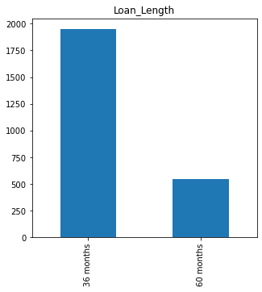

```python
loan_data['Loan_Length'].value_counts().plot.bar(figsize=(5,5),title='Loan_Length')
```

```
Max Loan application are of tenure 36 months.
Max Loan applicants have chosen the payment tenure to be 36 months over 60 months.
```

##### Loan Purpose

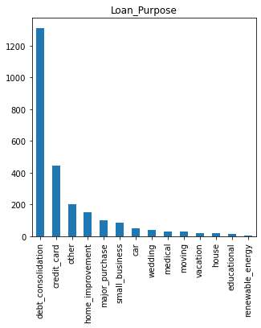

```python
loan_data['Loan_Purpose'].value_counts().plot.bar(figsize=(5,5),title='Loan_Purpose')
```

```
Maximum loan applications are for the purpose of debt consolidation.
```

##### Home Ownership

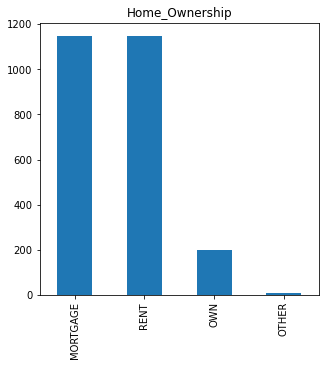

```python
loan_data['Home_Ownership'].value_counts().plot.bar(figsize=(5,5),title='Home_Ownership')
```

```
The loan applicants with highest loan applications are from Home ownership type Mortgage & Rent
```

##### Employment Length

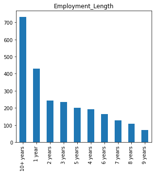

```python
loan_data['Employment_Length'].value_counts().plot.bar(figsize=(5,5),title='Employment_Length')
```

```
Maximum loan applicants have 10+ years of employment experience.
```

##### FICO Score

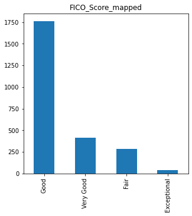

```python
loan_data['FICO_Score_mapped'].value_counts().plot.bar(figsize=(5,5),title='FICO_Score_mapped')
```

```
Most of the loan applicants have 'GOOD' FICO score. Applicants with Exceptional FICO score are few.
```

### Amount Requested

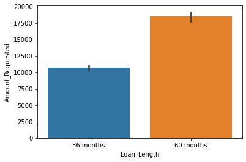

```python
sns.barplot(x = loan_data['Loan_Length'], y = loan_data['Amount_Requested'])
```

[output not shown]

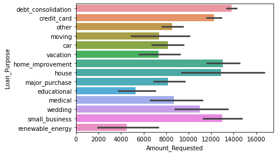

```python
sns.barplot(y = loan_data['Loan_Purpose'], x = loan_data['Amount_Requested'])
```

```
    The amount requested is highest for debt consolidation, credit card, home improvement (with less variability). The amount requested for the purpose of house, small business is also highest (with more variability).

    ####### Who are these applicants choosing these loan purpose? Find them #######
```

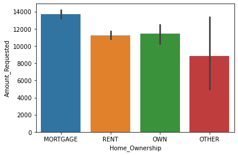

```python
sns.barplot(x = loan_data['Home_Ownership'], y = loan_data['Amount_Requested'])
```

[output not shown]

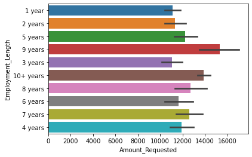

```python
sns.barplot(y = loan_data['Employment_Length'], x = loan_data['Amount_Requested'])
```

```
Avg. amount requested are highest for applicants with 9 yrs of employment length and we see high variability too.
Applicants with 9-10 yrs of employment length have the highest amt requested (avg.) in comparison with others.
Within 4-6 Yrs employment length, the avg. amount requested is similar.
for 7-8 ys of employment length, the avg. requested is similar.
Below 3 yrs of employment length, have similar amt requests (avg.)
** With increasing employment length, the requests for loan amount is higher - (may be) as per the ban's guidelines, as the credibility of these customers to repay is more than others.

##### Who are these applicants who fall under different employment length range - ownership type, loan purpose, loan length of them #####
```

### Amount Funded By Investor

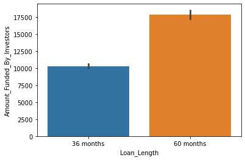

```python
sns.barplot(x = loan_data['Loan_Length'], y = loan_data['Amount_Funded_By_Investors'])
```

```
Investors funded more of those requests where applicants chose 60 months as payment tenure.

##### Find who are these applicants -ownership, employment length, loan purpose #####
```

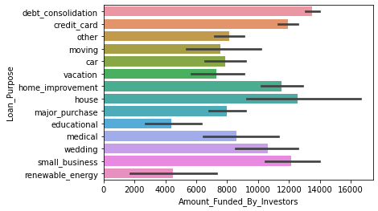

```python
sns.barplot(y = loan_data['Loan_Purpose'], x = loan_data['Amount_Funded_By_Investors'])
```

```
Investors funded (the avg.) mostly for loan purposes lie - debt consolidations, house (actuals may vary/maximum), small business. For credit cards, home improvements, weddings were funded subsequently. Least funded purpose are educational, renewable energy (** May be bcz lesser applicants)
#### Find who are these applicants - ownership, employment length, loan length ####
```

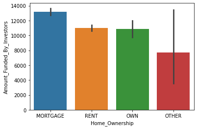

```python
sns.barplot(x = loan_data['Home_Ownership'], y = loan_data['Amount_Funded_By_Investors'])
```

```
Investors funded more for applicants with ownership type as Mortgage.
Investors funded equally for applicants with ownership types - Owners & on rent.
Investors funded lesser for 'Other' type of applicants. However, in few cases the amount invested would have been more~12000.

#### Who are these applicants with ownership type as mortgage, rent, owners, other ####
```

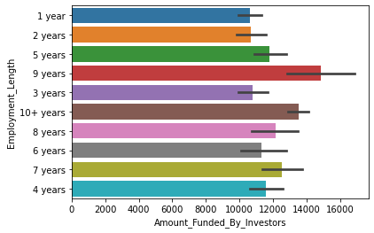

```python
sns.barplot(y = loan_data['Employment_Length'], x = loan_data['Amount_Funded_By_Investors'])
```

```
Investors funded more for applicants with 9 yrs of employment length and in few cases the amounts were more.
Applicants with 9-10 yrs of employment length have been funded the most (avg.) in comparison with others.
Within 4-6 Yrs employment length, amounts funded are similar.
For 7-8 yrs of employment length, similar range of amounts were funded.
Below 3 yrs of employment length, have similar funds invested.
** With increasing employment length, the funds invested is higher - (may be) as per the ban's guidelines, as the credibility of these customers to repay is more than others.

##### Who are these applicants who fall under different employment length range - ownership type, loan purpose, loan length of them #####
```

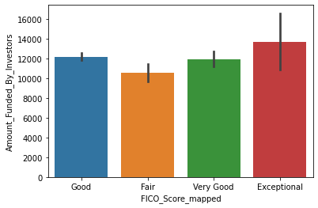

```python
sns.barplot(x = loan_data['FICO_Score_mapped'], y = loan_data['Amount_Funded_By_Investors'])
```

```
Investors funded applicants with exceptional FICO Score - more.
Funded less for applicants with Fair FICO score.

#### who are these applicants having different FICO score- ownership type, loan purpose, loan length ####
```